# Rejection Sampling in Nonparametric statistics

Abdulla Alhammadi

2022-12-15

## Introduction

The developments in the world of computing have had huge effects on the rate of progress in statistics. Enhanced computational capabilities that modern technology offers has boosted scope of statistics, and pushed the limits on what was possible and what is not. Part of this growth is what interested us, specifically rejection sampling. This report discusses rejection sampling and it’s applications and use relating to non-parametric statistical approaches.

## What is rejection sampling?

Rejection sampling, sometimes called the acceptance-rejection method, is a sampling method used to generate samples following a distribution. Rejection sampling is based on the idea of choosing samples from a distribution, called a sampling distribution, that fall under the PDF of a target distribution. If done enough times, the sample will resemble a distribution very close to the target distribution.

## Why is rejection sampling used?

Rejection sampling is often used for applications where a more traditional approach is limited. In relation to non-parametric statistics, there are three main components that will be discussed and demonstrated:

- It can be used with any distribution.
- It’s easy to modify it for different target distributions
- It can be used to generate any number of samples at once.

### Use with distributions

An advantage of this method is that it can be used to generate samples from a distribution even if the exact target distribution is not known. This makes it a useful tool for generating samples from unknown distributions, which is often the case when dealing with nonparametric statistics.

### Modification & optimization

It is relatively easy to modify the rejection sampling method, as it is a simple and flexible technique. Both components of rejection sampling (the sampling distribution, and the target distribution) can be easily modified to suit the specific needs of a given problem. For example, the sampling distribution can be changed to a different distribution that is better suited to the target distribution being sampled from, and the rejection threshold can be adjusted to achieve a desired balance between sample quality and computational efficiency by optimizing the sampling distributions parameters to reduce the number of iterations required to reach a specific sample size.

### Generating desired number of samples

Rejection sampling is effective and can be used to generate as much data as desired. Having the option to generate a desired sample size can improve the accuracy and precision of statistical models. However, with more data, it is possible to estimate model parameters more precisely, and this can lead to better predictions and more accurate inferences. Having more data can also improve the robustness of statistical models that can be built using data generated using rejection sampling. With more data, it is less likely that the model will be influenced by outliers or other unusual observations.

## The method & Algorithm

The method used for rejection sampling in a case where the target distribution has a PDF of $f(X)$ as follows:

1. Generate a random variable between 0 and 1 following a uniform distribution.
2. Generate a random variable $X$ from the sampling distribution (if the distribution to be sampled from is a normal distribution, for example, then $X \sim \mathcal{N(\mu,\,\sigma^{2})}$).
3. if $\frac{f(X)}{g(X)}$ is less than the generated value from the uniform distribution, then we accept the value $X$ as a variable following the distribution of $f(x)$. Otherwise, repeat from step 1 until the desired sample size is reached.

Visualizing how it works:

[figure not shown]

visual

The visualization above is good in demonstrating the process. The green curve represents the distribution to be sampled from, and the blue curve is a distribution with unknown parameters. Rejection sampling is trying to obtain a point that fits in both curves.

## Why is rejection sampling useful in non-parametric statistics?

Rejection sampling can be used in nonparametric statistics to generate random samples from a probability distribution that is not fully specified by a parametric model. In nonparametric statistics, the distribution of the data is not assumed to follow a specific distribution, such as a normal distribution or a gamma distribution. Instead, the shape of the distribution is estimated directly from the data using nonparametric techniques, such as kernel density estimation, which will be used in an example later on in this report. Once the distribution has been estimated, rejection sampling can be used to generate random samples from the estimated distribution.

### Statistical power

Nonparametric tests generally have less statistical power than parametric tests. This means that nonparametric tests are less likely to detect a true difference or relationship in the data, even if one exists. The reason for this is that parametric tests make assumptions about the underlying distribution of the data, such as the normality of the data. These assumptions allow parametric tests to make more efficient use of the data, and this leads to greater statistical power. Nonparametric tests, on the other hand, do not make any assumptions about the data, and this makes them less efficient at detecting differences or relationships in the data. For these reasons, rejection sampling can be used as a method to generate data toe run statistical tests where having high power is essential, which non-parametric tests do not always have the capability to do.

### Estimation of effects

Nonparametric tests are generally not as good as parametric tests for estimating the magnitude of an effect. Because nonparametric tests do not make any assumptions about the underlying distribution of the data, this makes it difficult to estimate the magnitude of an effect with precision. In contrast, parametric tests make assumptions about the data, such as the normality of the data, and these assumptions can be used to estimate the magnitude of an effect more precisely.

### Ties in dataset

Ties in the data can be a problem for nonparametric tests, because they can affect the calculations used to determine the test statistic. In nonparametric tests, the data are often ranked from lowest to highest, and the ranks are used in the calculations. If there are ties in the data, there may be multiple observations with the same rank, and this can make it difficult to calculate the test statistic accurately.

### Information about the target distribution

Nonparametric tests are limited by the fact that they do not make any assumptions about the underlying distribution of the data. This means that nonparametric tests do not use any information about the target distribution to make inferences or predictions. Instead, nonparametric tests use the empirical distribution of the data, which is estimated directly from the data, to make inferences or predictions. This can be a disadvantage in some situations, because the empirical distribution may not accurately represent the true underlying distribution of the data. For example, if the data are not normally distributed, a nonparametric test may not be able to detect a difference or relationship in the data that would be detectable using a parametric test.

### Use of more traditional approaches

By using rejection sampling, it is possible to apply traditional statistical methods, such as maximum likelihood estimation or Bayesian inference, to data that do not follow a known parametric distribution. This can allow us to use the full power of traditional statistical methods, even in situations where nonparametric tests would not be applicable.

## How to generate a PDF of data with no knowledge about the distribution?

For this case, we will use Kernel Density Estimation to generate a probability density function of a dataset where we don’t know the distribution function. Kernel density estimation is a nonparametric technique for estimating the probability density function of a random variable. To use kernel density estimation, you need a sample of observations from the unknown distribution. You can then use this sample to estimate the probability density function of the distribution using the kernel density estimation method. This involves placing a “kernel” function, such as a normal or uniform distribution, at each data point in the sample, and then summing these kernel functions to obtain an estimate of the probability density function of the unknown distribution. The kernel density estimation method has several parameters that can be adjusted to control the shape and smoothness of the estimated probability density function. These parameters can be chosen based on the characteristics of the data and the desired properties of the estimated probability density function.

This is the KDE function:

$$\hat{f}(x)=\frac{1}{n\triangle}\sum_{i=1}^n w(\frac{x-X_i}{\triangle})$$
Where $w$ is the kernel function, and $\triangle$ is the bandwidth parameter.

## Application

To demonstrate the effectiveness of the rejection method in the context of non-parametric sampling, we will R to generate a random sample of data that does not fit a specific distribution, find the Kernel Density Estimate to estimate the PDF, then use the PDF in a rejection sampling algorithm to sample data from the KDE using a normal distribution.

In an effort to make the data as random as possible, the data is generated by choosing from 3 random distributions with random parameters, and chooses one of the three values until we have a sample of 1000 values. Visualizing the data in a histogram looks like this:

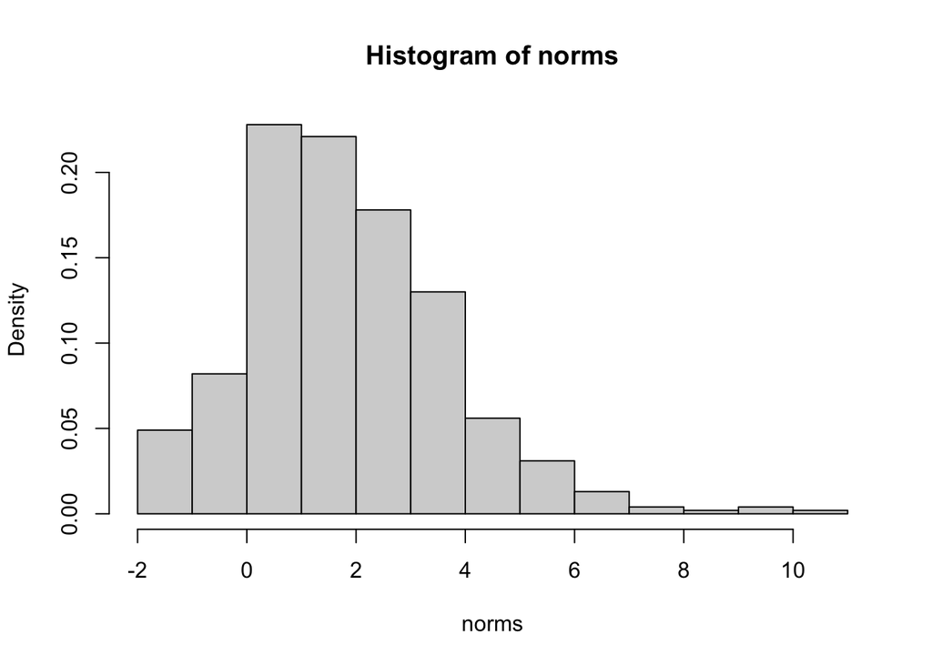

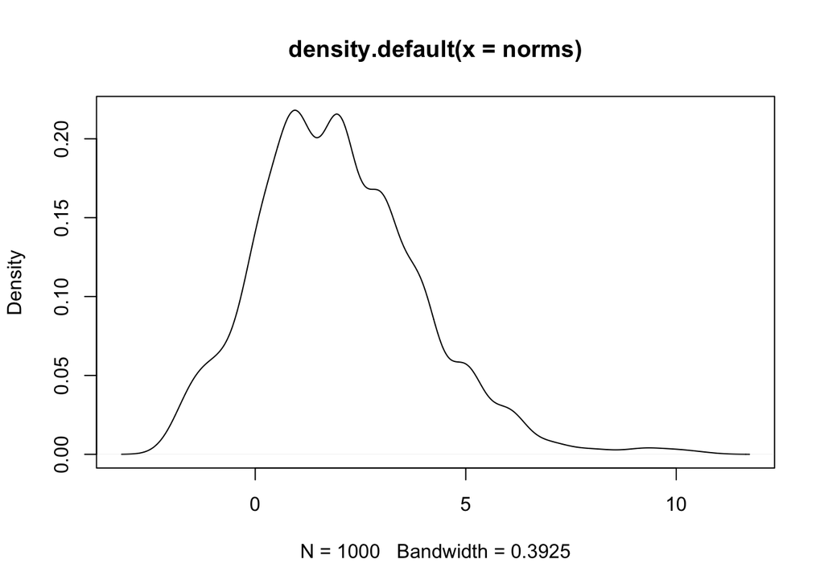

Now that we have the KDE of the PDF, we will use the algorithm discussed earlier to generate 10,000 samples. After we have generated the samples, plotting the generated data against the target dataset which was made of random data, this is what it looks like:

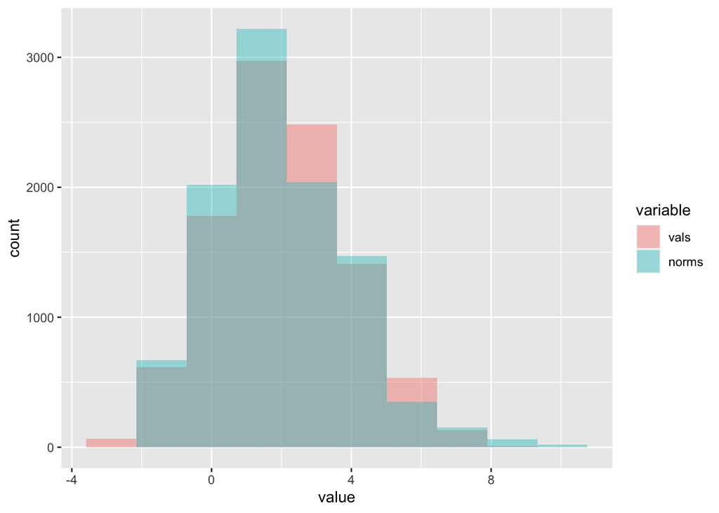

The blue plot represents the target data which we know nothing about, and the red plot is the data that we have generated using rejection sampling and KDE.

## Conclusion

Overall, this report sought to discuss the potential of rejection sampling and it’s potential applications when combined with non-parametric methods. Using R for this issue illustrates a modern approach to how we can combine the power of computations to do what some time ago was considered difficult. The three of us distributed the work proportionately, as in I did the code for the simulation, Samir did the plots, and Finnian did the write ups and reserach. We worked on writing the report together, which we believe we put equal effort.

## Citations

Casella, G., Robert, C. P., & Wells, M. T. (2004). Generalized accept-reject sampling schemes. Institute of Mathematical Statistics Lecture Notes - Monograph Series, 342–347. https://doi.org/10.1214/lnms/1196285403

Casella, G., Robert, C. P., & Wells, M. T. (2004, January 1). Generalized accept-reject sampling schemes. Project Euclid. Retrieved December 16, 2022, from https://projecteuclid.org/ebooks/institute-of-mathematical-statistics-lecture-notes-monograph-series/A-Festschrift-for-Herman-Rubin/chapter/Generalized-Accept-Reject-sampling-schemes/10.1214/lnms/1196285403

Lecture 4: Importance sampling and rejection sampling. (n.d.). Retrieved December 17, 2022, from https://faculty.washington.edu/yenchic/17Sp_403/Lec4_Importance.pdf

Leise, M. 365 P. (n.d.). Rejection sampling. Retrieved December 16, 2022, from https://tleise.people.amherst.edu/Math365Spring2016/RmarkdownFiles/RejectionSampling.html

Peng, R. D. (2022, May 27). Advanced statistical computing. Home. Retrieved December 16, 2022, from https://bookdown.org/rdpeng/advstatcomp/